# Notebook 5 Exploring Relationships and Trends (Teacher)

## Notebook 5: Exploring Relationships & Trends in Survey Data

In the previous notebooks, you practiced using summary statistics and visualizations to explore variables and relationships in survey data. Those examples were chosen to help you learn key data manipulation and visualization techniques.

In this notebook, you will apply those same skills in a more independent way. You will choose your own variables from the dataset, develop a data question, and examine how responses differ between groups and how those differences have changed (or not) over time. To do this, prepare your data, summarize it, create visualizations, and describe what you notice. Your goal is to investigate patterns in the perceptions of U.S. residents using data summaries and visualizations.

For a more detailed description of each step, see [here](https://docs.google.com/document/d/1n07ZjONS0cJ35WldDhheSjbx9_zHRpWl-AUwubYX2OY/edit?tab=t.z3on2bm27w66).

As in the previous notebook, we continue to use Pandas to load, organize, and summarize the data, and Matplotlib (via `matplotlib.pyplot`) to create visualizations.

```python
## Run this code but do not edit it. Hit Ctrl+Enter to run the code
# This command imports `pandas` library and creates an alias named `pd`
import pandas as pd

# This command imports the `matplotlib.pyplot` module and creates an alias named `plt`
import matplotlib.pyplot as plt
plt.rcParams["figure.figsize"]=(12, 6)
```

To begin, let's download our data. We'll download the `updated_gss.csv`from a URL and stores it into an `pandas` `DataFrame` object called `gss`.

### The Dataset (`updated_gss.csv`)

**General description:** The [General Social Survey (GSS)](https://gss.norc.org/) is a nationally representative survey of adults in the United States that was started in 1972. Conducted by the non-partisan [National Opinion Research Center (NORC)](https://www.norc.org/), the GSS collects data on a wide variety of topics in contemporary American society, including civil liberties, crime, intergroup tolerance, and social mobility. Its core purpose is to monitor and explain trends in opinions, attitudes, and behaviors.

The dataset used in this notebook is a subset of the full GSS, containing selected variables and survey years chosen to support instructional exploration and analysis. t also includes a cleaned version of the `wwwhr` column, with text-based response codes removed, replaced by missing values (`NA`), and remaining values converted to numeric.

**Description of all variables:** See [here.](https://ds4e-org.github.io/ap-cs-dsc/var.html)

**Detailed data file description:** See [here.](https://docs.google.com/spreadsheets/d/1AC6ZEz_00ZjoBBWrBpAgnybOqzFOsKFX/edit?gid=61928758#gid=61928758)

```python
## Run this code but do not edit it. Hit Ctrl+Enter to run the code
# This command downloads the data and stores it in the object gss
base_url = "https://raw.githubusercontent.com/ds4e-org/ap-cs-dsc/main/data/"
filename = "updated_gss.csv"
url = base_url + filename

gss = pd.read_csv(url)
```

### 1.0 - Choose Your Variables

Before selecting your variables, take a few minutes to explore what is available in the dataset.

#### Step 1: Explore the variables

- Open the list of variables [here](https://ds4e-org.github.io/ap-cs-dsc-student/var.html).
- Look through the variable names and descriptions to identify topics of interest
- Use the [category groupings](https://ds4e-org.github.io/ap-cs-dsc-student/var.html#categories-years) to find related variables and see which years they are available.
- Read the [survey questions](https://ds4e-org.github.io/ap-cs-dsc-student/var.html#categories-years) for any variables you are considering to understand what the responses represent
- Take note of the codes used for [missing and non-substantitative](https://ds4e-org.github.io/ap-cs-dsc-student/var.html#missing-non-substantive-codes) responses

**1.1 -** List 2 numerical variables and 3 cagegorical variables that you found to be intesting.

**Double-click to type a response:**

**Numerical Variables**

- Variable 1:
- Variable 2:

**Categorical Variables**

- Variable 1:
- Variable 2:
- Variable 3:`

**Sample Response**  
**Numerical Variables**

- Variable 1: `moredays`
- Variable 2: `hrsrelax`

**Categorical Variables**

- Variable 1: `coldeg1`
- Variable 2: `born`
- Variable 3: `goodlife`

**Example:** Your variables should include at least one numerical variable and one categorical variable that you can use to compare groups and explore patterns over time.

#### Step 2: Examine your variables

Now examine each of the variables you selected to understand what values appear in the data before beginning your analysis. A good variable to investigate is one that shows interesting patterns or differences.

- Your numerical variable will allow you to measure or calculate values
- Your categorical variable will allow you to compare groups
- You will also use `survey_year` to examine change over time

As you explore your variables, pay attention to missing or non-substantive responses, as you may need to filter these before analyzing your data.

Before moving on, display the values in each of your selected variables to understand what appears in the data.

**1.2 –** Display the values in the **numerical** columns for the variables you selected (for example, `df["column_name"]`) to see what appears in the data.

**Hint:** If your output shows mostly `NaN` values:

1. Create a mask to identify values that are not missing using `.notna()`.
2. Use that mask to filter the DataFrame.
3. Select the column to display only the non-missing values.

**How this works:**  
`.notna()` returns **True** for values that are not missing and **False** for missing values (`NaN`).

**Example code structure:**  
`mask = df["column_name"].notna()`  
`df[mask]["column_name"]`

```python
## List your numerical variable here
# Your code goes here
moredays_mask = gss["moredays"].notna()
gss[moredays_mask]["moredays"]
```

```
2995      5.0
2996      8.0
2997      5.0
2998     10.0
2999      6.0
         ...
20144     3.0
20145     6.0
20146     4.0
20147    20.0
20148     1.0
Name: moredays, Length: 6267, dtype: float64
```

```python
## List your numerical variable here
# Your code goes here
hrsrelax_mask = gss["hrsrelax"].notna()
gss[hrsrelax_mask]["hrsrelax"]
```

```
2995     3.0
2996     2.0
2997     1.0
2998     0.0
2999     6.0
        ...
20144    8.0
20145    1.0
20146    3.0
20147    4.0
20148    1.0
Name: hrsrelax, Length: 6294, dtype: float64
```

**1.3 –** Display the values in the **categorical** columns for the variables you selected (for example, `df["column_name"]`) to see what appears in the data.

**Hint:** If your output shows mostly non-substantive or missing values values:

1. Create a list of non-substantive categories (such as `".i: Inapplicable"`, `".n: No answer"`, `".d: Do not Know/Cannot Choose"`, `.s: Skipped on Web`, and `".y: Not available in this year"`).
2. Create a mask using `.isin()` to identify those categories.
3. Use the `~` operator to reverse the mask and keep only substantive responses.
4. Select the column to display the filtered values.

**How this works:**  
`.isin()` returns **True** for values that match the list. The `~` operator reverses this, so you keep values that are **not** in the list.

**Example code structure:**  
`non_substantive = ["..."]`  
`mask = df["column_name"].isin(non_substantive)`  
`df[~mask]["column_name"]`

```python
## List your categorical variable here
# Your code goes here
non_substantive = [".i:  Inapplicable",
                   ".n:  No answer",
                   ".d:  Do not Know/Cannot Choose",
                   ".y:  Not available in this year",
                   ".s:  Skipped on Web"]
coldeg1_mask = gss["coldeg1"].isin(non_substantive)
gss[~coldeg1_mask]["coldeg1"]
```

```
6467     ASSOCIATE'S
6471      BACHELOR'S
6474      BACHELOR'S
6477      BACHELOR'S
6483      BACHELOR'S
            ...
16631     BACHELOR'S
16634       MASTER'S
16642    ASSOCIATE'S
16647    ASSOCIATE'S
16672     BACHELOR'S
Name: coldeg1, Length: 1884, dtype: object
```

```python
## List your categorical variable here
gss["born"]
```

```
0        YES
1        YES
2        YES
3        YES
4        YES
        ...
21753    YES
21754    YES
21755    YES
21756     NO
21757    YES
Name: born, Length: 21758, dtype: object
```

```python
## List your categorical variable here
# Your code goes here
gss["goodlife"]
```

```
0                 Disagree
1                 Disagree
2                 Disagree
3                    Agree
4                    Agree
               ...
21753             Disagree
21754    Strongly disagree
21755                Agree
21756             Disagree
21757    Strongly disagree
Name: goodlife, Length: 21758, dtype: object
```

**Keep in mind:** You do not need to write everything from the output. Focus on key values, categories, or patterns you may want to refer back to later.

### 2.0 – Summarize Your Variables

Now you will summarize the variables you selected to better understand how their values are distributed.

#### Step 1: Summarize each variable individually

Examine each of your selected variables:

- Use `.describe()` for your numerical variable to examine the distribution (mean, median, range)
- Use `.value_counts()` for your categorical variable to examine how responses are distributed across categories (counts), or convert counts to proportions to compare relative frequencies

**2.1 –** Summarize each **numerical** variable you selected using `.describe()`.

```python
## Summarize your numerical variable here
# Your code goes here
gss["moredays"].describe()
```

```
count    6267.000000
mean        5.641615
std         7.503006
min         0.000000
25%         0.000000
50%         3.000000
75%         7.000000
max        31.000000
Name: moredays, dtype: float64
```

```python
## Summarize your numerical variable here
# Your code goes here
gss["hrsrelax"].describe()
```

```
count    6294.000000
mean        3.617890
std         2.784661
min         0.000000
25%         2.000000
50%         3.000000
75%         5.000000
max        24.000000
Name: hrsrelax, dtype: float64
```

**2.2 –** Summarize each **categorical** variable you selected using `.value_counts()`. You may also examine relative frequencies (proportions) to understand how responses are distributed.

```python
## Summarize your categorical variable here
# Your code goes here
gss["sex"].value_counts()
```

```
sex
FEMALE                            11981
MALE                               9758
.i:  Inapplicable                     9
.d:  Do not Know/Cannot Choose        5
.s:  Skipped on Web                   4
.n:  No answer                        1
Name: count, dtype: int64
```

```python
## Summarize your categorical variable here
# Your code goes here
gss["region"].value_counts()
```

```
region
South        8223
Midwest      5110
West         4893
Northeast    3532
Name: count, dtype: int64
```

```python
## Summarize your categorical variable here
# Your code goes here
gss["born"].value_counts()
```

```
born
YES                               17921
NO                                 2862
.i:  Inapplicable                   925
.d:  Do not Know/Cannot Choose       26
.n:  No answer                       16
.s:  Skipped on Web                   8
Name: count, dtype: int64
```

```python
## Summarize your categorical variable here
# Your code goes here
gss["goodlife"].value_counts()
```

```
goodlife
.i:  Inapplicable                 8810
Agree                             5794
Strongly agree                    2351
Neither                           2211
Disagree                          1987
Strongly disagree                  525
.d:  Do not Know/Cannot Choose      53
.n:  No answer                      20
.s:  Skipped on Web                  7
Name: count, dtype: int64
```

**Keep in mind:** If most of the responses are non-substantive (such as `.i: Inapplicable`, `.d: Do not Know/Cannot Choose`, `.n: No answer`, or `.s: Skipped on Web`), the summary may not reflect meaningful responses. You may need to filter these categories before continuing your analysis, especially when comparing proportions.

**2.3 –** Choose one **numerical** variable and one **categorical** variable from your list to use for the rest of your analysis.

**Double-click to type a response:**

**Numerical Variable:** `moredays`

**Categorical Variable:** `goodlife`

**Sample Response**

**Numerical Variable:** `moredays`

**Categorical Variable:** `goodlife`

### 3.0 – Write Your Data Question

#### Step 1: Write your data question

Now that you have examined and summarized your variables, write a question that you can answer using your data.

You will use:

- your **numerical variable** to measure values
- your **categorical variable** to compare groups

> **Important:** Your question should involve both variables.

How you frame your question depends on your numerical variable:

- Compare values across groups (for example, How does income vary by education level?)
- **Optional:** Include `survey_year` to examine how this relationship changes over time (for example, compare your variable across groups within each year).

**Examples**

- How does the number of days per month working extra hours (`moredays`) vary across responses to the “good life” question (`goodlife`)?
- How has the average number of days per month working extra hours (`moredays`) changed over time (`survey_year`)?
- How has the average number of days per month working extra hours (`moredays`) changed over time (`survey_year`) across different “good life” responses (`goodlife`)?

**3.1 –** Write your data question.

### 4.0 – Use the Data to Answer Your Question

Now that you have defined your question, you will use the data to answer it by following a series of steps.

#### Step 1: Compare values across groups

- Group your data by your categorical variable
- Calculate summary statistics (mean and median)
- Create a boxplot to compare values across groups

**4.1 –** Write code to group your data by your **categorical** variable and calculate summary statistics (such as the mean and median) for your **numerical** variable.

```python
## Group by your categorical variable and display the mean
# Your code goes here
gss.groupby("goodlife")["moredays"].mean()
```

```
goodlife
.d:  Do not Know/Cannot Choose     1.200000
.i:  Inapplicable                  5.592636
.n:  No answer                    15.000000
.s:  Skipped on Web                0.000000
Agree                              5.561062
Disagree                           5.587922
Neither                            5.561600
Strongly agree                     6.254786
Strongly disagree                  5.177966
Name: moredays, dtype: float64
```

```python
## Group by your categorical variable and display the meadian
# Your code goes here
gss.groupby("goodlife")["moredays"].median()
```

```
goodlife
.d:  Do not Know/Cannot Choose     0.0
.i:  Inapplicable                  3.0
.n:  No answer                    15.0
.s:  Skipped on Web                0.0
Agree                              3.0
Disagree                           3.0
Neither                            2.0
Strongly agree                     4.0
Strongly disagree                  2.0
Name: moredays, dtype: float64
```

**4.2 –** Describe how your **numerical** variable varies across the categories of your **categorical** variable.

In your response:

- Compare the mean and median values across groups
- Describe any similarities or differences you observe
- Identify any categories that may not be meaningful for analysis

**Double-click to type a response:**

**Sample Response**  
**Main Takeaways**

- The mean number of extra workdays (`moredays`) is fairly similar across most substantive categories of `goodlife`, generally around 5.5 to 6.2 days per month.
- The median values are much lower (between 2 and 4 days), suggesting the data is skewed. This means a smaller number of respondents report many extra workdays, which pulls the mean upward.
- Respondents who “Strongly agree” with `goodlife` report slightly more extra workdays on average, while those who “Strongly disagree” report slightly fewer.
- However, the differences across groups are relatively small.

**Important Observation**

- Some categories (such as `“.i: Inapplicable”` and `“.n: No answer”`) have unusual values (for example, mean = 15), which are not meaningful.
- These are non-substantive responses and should be filtered out before interpreting results.

**Overall Interpretation:**

- There is a slight relationship between life satisfaction (`goodlife`) and the number of extra workdays (`moredays`), but the relationship is not strong.
- The skew in the data suggests that the median may better represent a typical number of extra workdays.

**Instructor Note:** At this stage, students are not expected to provide a deep statistical interpretation. An acceptable response should describe observable patterns in the output, such as comparing mean and median values across groups, noting whether values are similar or different, and identifying any non-substantive categories (e.g., `“.i: Inapplicable”`, `“.n: No answer”`) that may need to be removed.

Students may notice that the mean is higher than the median or that differences across groups are small, but they are not required to use formal terms such as "skewed distribution" or make strong claims about relationships. The goal is for students to describe what they see clearly and use specific values from the output to support their observations.

**4.3 –** Create a boxplot to visualize how your **numerical** variable is distributed across the categories of your **categorical** variable.

**Hint:** You can create a list of substantive categories and use `.isin()` to filter your data before creating the boxplot.

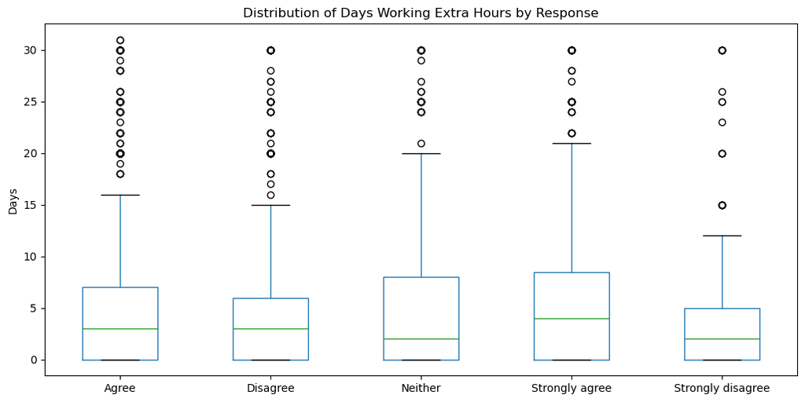

```python
## Create a boxplot
# Your code goes here
goodlife_responses = ["Agree", "Disagree", "Neither", "Strongly agree", "Strongly disagree"]
goodlife_mask = gss["goodlife"].isin(goodlife_responses)
gss[goodlife_mask].boxplot(column="moredays", by="goodlife", grid=False)
plt.xlabel("")
plt.ylabel("Days")
plt.title("Distribution of Days Working Extra Hours by Response")
plt.suptitle("")
plt.show();
```

**Optional:** If you would like to improve your graph by customizing the title, axis labels, ticks, or legend, see the visualization help page here: [Customize Your Graph](https://ds4e-org.github.io/ap-cs-dsc-student/visualization.html).

#### Step 2: Examine change over time

- Group your data by `survey_year`
- Calculate summary statistics
- Create a line chart to examine how values change over time

**4.4 –** Group your data by `survey_year` and calculate the mean for your **numerical** variable. Save the result to a variable, then display the table by typing the variable name.

**Watch out:** If your table includes `NaN` values, you may need to remove them before interpreting your results. Consider dropping missing values before displaying your table.

```python
## Group by survey year and calculate the mean
# Your code goes here
moredays_tbl = gss.groupby("survey_year")["moredays"].mean().dropna()
moredays_tbl
```

```
survey_year
2002    5.692716
2006    6.128478
2010    5.884715
2014    5.480000
2018    5.738043
2022    4.996032
Name: moredays, dtype: float64
```

**4.5 –** Create a line chart using your summary table to examine how your **numerical** variable changes over time.

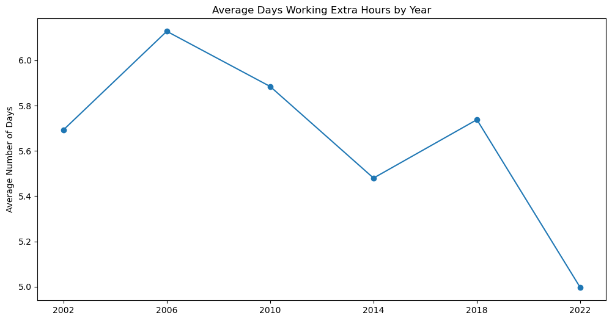

```python
## Create a line chart
# Your code goes here
moredays_tbl.plot(marker="o")
plt.xticks(range(2002, 2026, 4))
plt.xlabel("")
plt.ylabel("Average Number of Days")
plt.title("Average Days Working Extra Hours by Year")
plt.show();
```

**Optional:** If you would like to improve your graph by customizing the title, axis labels, ticks, or legend, see the visualization help page here: [Customize Your Graph](https://ds4e-org.github.io/ap-cs-dsc-student/visualization.html).

#### Step 3: Compare change over time across groups

- First, filter your data to include only the **substantive categories** for your categorical variable
- Group your data by `survey_year` and your categorical variable
- Calculate summary statistics
- Create a multiple line chart to compare trends across groups

**4.6 –** Create a list of the **substantive categories** for your **categorical** variable. Then use this list to filter the `gss` so that it includes only these categories. Save the result to a new variable.

```python
## Create the list of responses and filter the datafrane
# Your code goes here
goodlife_responses = ["Agree", "Disagree", "Neither", "Strongly agree", "Strongly disagree"]
goodlife_mask = gss["goodlife"].isin(goodlife_responses)
goodlife_df = gss[goodlife_mask]
```

**4.7 –** Use your new dataframe to group your data by `survey_year` and your **categorical** variable, and calculate the mean for your **numerical** variable. Save the result to a variable.

**Watch out:** If your output contains missing values (`NaN`), drop these rows before displaying the table.

```python
## Group by survey year and your categorical variable
# Your code goes here
goodlife_tbl = goodlife_df.groupby(["survey_year", "goodlife"])["moredays"].mean().dropna()
```

**4.8 –** Use `.unstack()` on your summary table to reorganize the data so that each category of your **categorical** variable appears as a separate column.

```python
## Display your table
# Your code goes here
goodlife_tbl
```

```
survey_year  goodlife
2002         Agree                6.229075
             Disagree             4.942308
             Neither              7.000000
             Strongly agree       6.873874
             Strongly disagree    9.857143
2006         Agree                6.102138
             Disagree             5.588889
             Neither              5.903509
             Strongly agree       6.563536
             Strongly disagree    3.470588
2010         Agree                6.279070
             Disagree             5.125000
             Neither              5.400000
             Strongly agree       5.732558
             Strongly disagree    9.533333
2014         Agree                4.934959
             Disagree             5.186047
             Neither              6.400000
             Strongly agree       5.630137
             Strongly disagree    2.250000
2018         Agree                5.114754
             Disagree             5.771084
             Neither              5.803738
             Strongly agree       6.814159
             Strongly disagree    3.307692
2022         Agree                4.693950
             Disagree             6.211538
             Neither              4.584211
             Strongly agree       5.408696
             Strongly disagree    5.000000
Name: moredays, dtype: float64
```

**4.9 –** Use your summary table to create a line chart that shows how your **numerical** variable changes over time for each category of your **categorical** variable.

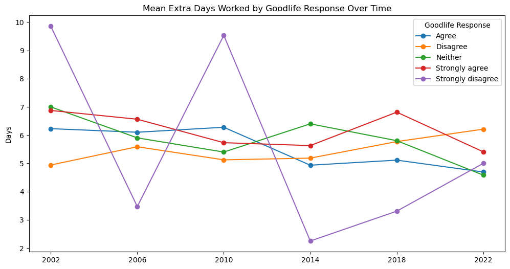

```python
## Create a multiple line chart
# Your code goes here
goodlife_tbl.unstack().plot(marker="o")
plt.xticks(range(2002, 2026, 4))
plt.xlabel("")
plt.ylabel("Days")
plt.title("Mean Extra Days Worked by Goodlife Response Over Time")
plt.legend(title="Goodlife Response")
plt.show();
```

**Optional:** If you would like to improve your graph by customizing the title, axis labels, ticks, or legend, see the visualization help page here: [Customize Your Graph](https://ds4e-org.github.io/ap-cs-dsc-student/visualization.html).

### 5.0 – Answer Your Question

Now use your analysis and visualizations to answer your question.

#### Step 1: Describe what you see

Look at your summaries (such as tables or calculated values) and graphs.

- What are the most important patterns or trends?
- How do values differ across groups or over time?
- What evidence from your tables or graphs supports these observations?

**Keep in mind:** You do not need to describe every detail in your summaries or graphs. Focus on the key values, patterns, trends, or differences that help answer your question.

**5.1 –** Use the markdown cell below to describe what you observe in your summaries and graphs. Be specific and refer to patterns, trends, or differences you see.

**Double-click to type a response:**

**Sample Response**

The summaries and graphs show that the mean number of extra days worked per month is fairly similar across the goodlife response categories, but there are some differences. In the grouped summary, respondents who selected “Strongly agree” generally had the highest mean number of extra workdays, while respondents who selected “Disagree” or “Agree” tended to have slightly lower means. The boxplot also shows that the distributions overlap a lot across groups, although some categories have slightly higher medians and more spread than others.

Over time, the overall mean number of extra workdays changes somewhat, rising from about 5.69 in 2002 to about 6.13 in 2006, then decreasing to about 5.00 in 2022. When the data are separated by goodlife category, the graph shows that some groups change more than others. For example, the “Strongly disagree” group varies a lot across years, while other groups such as “Agree” and “Disagree” are more stable. Overall, the graph suggests some differences across goodlife groups, but the trends are not perfectly consistent over time.

**Instructor Note:** A typical student response should describe the main patterns they observe in their summaries and graphs. Students should identify key trends, similarities, or differences and refer to specific values or features (such as higher/lower groups or changes over time).

It is acceptable for students to:

- Describe general patterns (e.g., values are similar across groups or change over time)
- Make simple comparisons between groups or years
- Reference at least one specific value or feature from a table or graph

Students are not expected to explain why patterns occur. The focus is on clearly describing what they see using evidence from their analysis.

#### Step 2: Answer your question

Use your observations to answer your question.

- What does your analysis suggest?
- Support your answer with at least one specific value, comparison, or trend.

**5.2 –** Use the markdown cell below to clearly answer your question.

- State your answer in complete sentences.
- Support your answer with at least one specific value, comparison, or trend.
- You may write in sentences or short paragraphs.

**Double-click to type a response:**

**Sample Response**

The analysis suggests that the number of extra days respondents work beyond their usual schedule varies somewhat across levels of satisfaction with life, but the relationship is not very strong. Respondents who selected “Strongly agree” often had a slightly higher mean number of extra workdays than other groups, while groups such as “Agree” and “Disagree” were usually somewhat lower. For example, in the grouped summary, the mean for “Strongly agree” was about 6.25, compared with about 5.56 for “Agree”.

Over time, this relationship changes somewhat, but the overall pattern is not completely consistent. The overall mean number of extra workdays peaks around 2006 (6.13) and then declines to about 5.00 in 2022. In the multiple-line graph, some goodlife categories remain relatively stable, while others fluctuate more from year to year. This suggests that satisfaction with life may be related to extra workdays, but the differences across groups are fairly modest and vary over time.

**Instructor Note:** A typical student response should clearly answer the question they wrote using their observations. Students should state a conclusion and support it with at least one specific value, comparison, or trend from their analysis.

It is acceptable for students to:

- State a clear answer to their question
- Use evidence from their summaries or graphs to support their answer
- Make simple, reasonable claims based on the data

Students are not expected to provide detailed explanations or causal reasoning. The goal is to connect their observations to a clear, evidence-based answer.

**Optional:** Try repeating this process with different variables or by asking a different type of question (compare across groups, examine change over time, or both) to explore new patterns in the data.